# Tarea 4

Aldair Gándara Hernández & Emmanuel Garduño Tellez

19/10/2021

# MODELO PROBABILÍSTICO PARA LLUVIAS EN MÉXICO

LECTURA DE DATOS

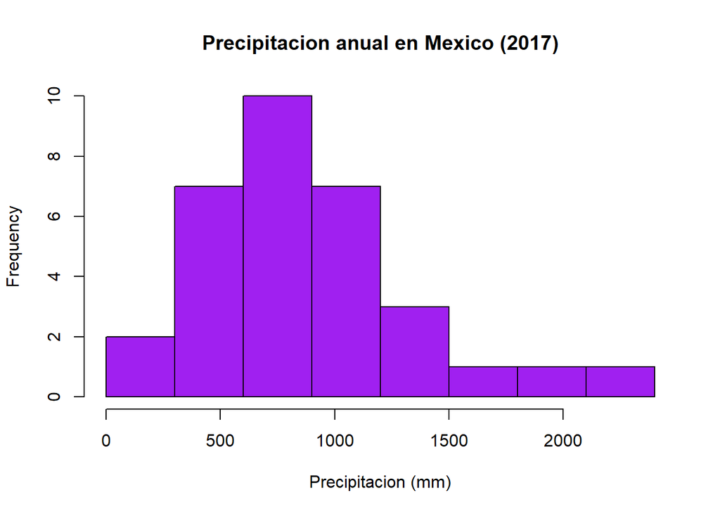

```r
library(knitr)
setwd("D:/Documentos/Estadistica_Computacional")
lluvias= read.table("lluvias.dat",sep="\t",row.names = 1,header=T)
attach(lluvias)
y= Precipitacion   # renombro la variable por comodidad

# Graficamos los datos para "ver" el perfil que describen.
hist(y,breaks=seq(0,2400,300),main= "Precipitacion anual en Mexico (2017)",
     xlab="Precipitacion (mm)", col="purple")
```

## Estimación de Parámetros por Mínimos Cuadrados

El método empleado para estimar los parámetros iniciales será por el Método de Mínimos Cuadrados, es decir, se hará una linealización de la función acumulativa de la forma:

$$ln( -ln(1-\hat{F}(x))) = \alpha \ln(x) - \alpha ln(\beta)$$

Primero ordenamos las observaciones de menor a mayor:

```r
N<-length(y)

pre_ord<-sort(y); pre_ord
```

```
##  [1]  183  200  341  425  436  473  499  516  571  613  618  713  716  765  778
## [16]  795  815  830  863  942  945  957 1078 1099 1116 1198 1276 1278 1489 1511
## [31] 1995 2396
```

La $\hat{F}(x_{i})$ se estima dividiendo la posición $i$ entre el total de observaciones $n$.

```r
prob_acum<-function(t){
  is<-seq(1, length(t), 1)
  Fis<-is/length(t)
  return(Fis)
}

F_t<-prob_acum(pre_ord)

##Para eviatar indeterminaciones el último valor estimado es 1, lo cual provocará una indeterminación en los Logarrotmos, se redondea a:

F_t[length(F_t)]=0.9999; F_t
```

```
##  [1] 0.03125 0.06250 0.09375 0.12500 0.15625 0.18750 0.21875 0.25000 0.28125
## [10] 0.31250 0.34375 0.37500 0.40625 0.43750 0.46875 0.50000 0.53125 0.56250
## [19] 0.59375 0.62500 0.65625 0.68750 0.71875 0.75000 0.78125 0.81250 0.84375
## [28] 0.87500 0.90625 0.93750 0.96875 0.99990
```

Calculamos $X_{i} = ln(x_{i})$ y $Y_{i}=ln(-ln(1-\hat{F}(x)))$ y mostramos una primera gráfica:

```r
yi<-log(-log(1-F_t, base = exp(1)), base=exp(1)); yi
```

```
##  [1] -3.44990355 -2.74049301 -2.31830731 -2.01341868 -1.77255092 -1.57195253
##  [7] -1.39893359 -1.24589932 -1.10793051 -0.98164706 -0.86461553 -0.75501486
## [13] -0.65143549 -0.55275214 -0.45803939 -0.36651292 -0.27748662 -0.19033933
## [19] -0.10448696 -0.01935689  0.06563851  0.15113254  0.23784403  0.32663426
## [25]  0.41859569  0.51520189  0.61858418  0.73209937  0.86167555  1.01978144
## [31]  1.24292499  2.22032681
```

```r
xi<-log(pre_ord, base=exp(1)); xi
```

```
##  [1] 5.209486 5.298317 5.831882 6.052089 6.077642 6.159095 6.212606 6.246107
##  [9] 6.347389 6.418365 6.426488 6.569481 6.573680 6.639876 6.656727 6.678342
## [17] 6.703188 6.721426 6.760415 6.848005 6.851185 6.863803 6.982863 7.002156
## [25] 7.017506 7.088409 7.151485 7.153052 7.305860 7.320527 7.598399 7.781556
```

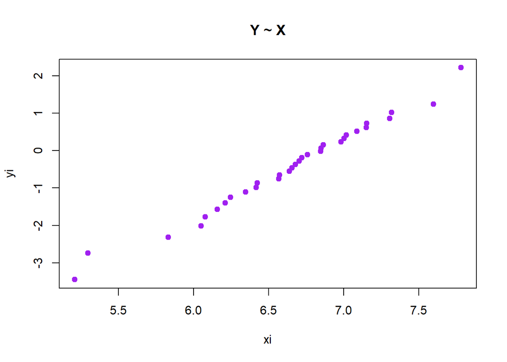

```r
plot(xi, yi, col="purple", type="p", main=" Y ~ X ", pch=19)
```

Para obtener la regresión lineal se hará de 2 formas: Por la función lm() de R y calculando ambos coeficientes de forma manual.

```r
#Forma 1:

dats<-data.frame("X"=xi, "Y"=yi)

reg<-lm(Y~X, data=dats); reg
```

```
##
## Call:
## lm(formula = Y ~ X, data = dats)
##
## Coefficients:
## (Intercept)            X
##     -14.349        2.092
```

```r
summary(reg)
```

```
##
## Call:
## lm(formula = Y ~ X, data = dats)
##
## Residuals:
##      Min       1Q   Median       3Q      Max
## -0.32792 -0.06595  0.00225  0.05820  0.52218
##
## Coefficients:
##              Estimate Std. Error t value Pr(>|t|)
## (Intercept) -14.34876    0.32646  -43.95   <2e-16 ***
## X             2.09238    0.04897   42.73   <2e-16 ***
## ---
## Signif. codes:  0 '***' 0.001 '**' 0.01 '*' 0.05 '.' 0.1 ' ' 1
##
## Residual standard error: 0.1574 on 30 degrees of freedom
## Multiple R-squared:  0.9838, Adjusted R-squared:  0.9833
## F-statistic:  1826 on 1 and 30 DF,  p-value: < 2.2e-16
```

```r
#Forma 2:

a=(N*(sum(xi*yi))-sum(xi)*sum(yi))/(N*sum(xi*xi)-sum(xi)^2)

b=(sum(xi*xi)*sum(yi)-sum(xi*yi)*sum(xi))/(N*sum(xi*xi)-sum(xi)^2)

alfa_WE<-a
print("Alfa"); alfa_WE
```

```
## [1] "Alfa"
```

```
## [1] 2.092379
```

```r
beta_WE<-exp(-(b/alfa_WE))
print("Beta"); beta_WE
```

```
## [1] "Beta"
```

```
## [1] 951.1105
```

```r
lambda_WE<-1/beta_WE
print("Lambda"); lambda_WE
```

```
## [1] "Lambda"
```

```
## [1] 0.001051403
```

## Función log_verosimilitud

Función de LOG_Verosimilitud de un Weibull:

$$\mathscr{L}(\beta, \alpha, \hat{x}) = n \ln(\alpha) - n \alpha \ln(\beta) + (\alpha -1)\sum_{i=1}^{n}\ln(x_{i}) - \sum_{i=1}^n (\frac{x_{i}}{\beta})^\alpha$$

```r
log_lik_wei<-function( parms){

  alfa=parms[1]
  lambda=parms[2]
  nn=length(y)

  llw=(nn*log(alfa, base = exp(1))) - (nn*alfa*log(1/lambda, base = exp(1))) +
    ((alfa-1)*sum(log(y, base = exp(1)))) -
    sum((y*lambda)^alfa)
  return(-llw)
}

lluvias_Wei<-optim(c(alfa_WE, lambda_WE), log_lik_wei); lluvias_Wei$par
```

```
## [1] 1.972515597 0.000994608
```

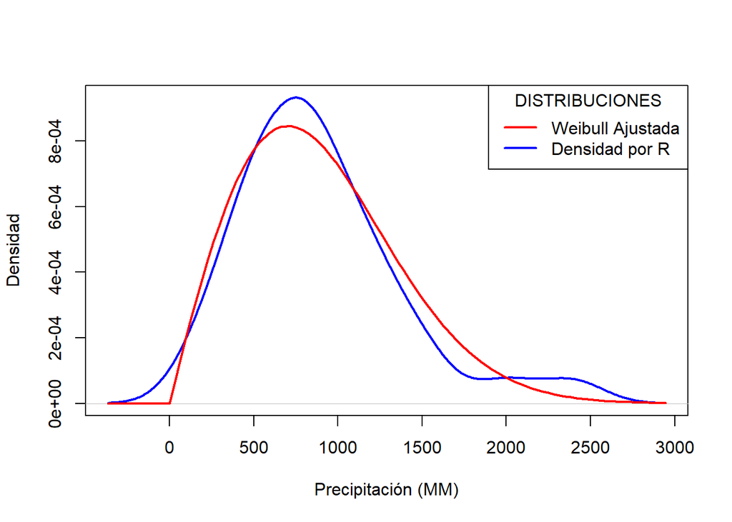

```r
plot(density(y), col="blue", lwd=2, xlab="Precipitación (MM)", ylab="Densidad", main="")
curve(dweibull(x, lluvias_Wei$par[1], 1/lluvias_Wei$par[2]), col="red", lwd=2, add=T)

legend(x = "topright",         # Posición
       legend = c("Weibull Ajustada", "Densidad por R"), # Textos de la leyenda
       title = "DISTRIBUCIONES",
       lty = c(1, 1),          # Tipo de líneas
       col = c("red", "blue"),          # Colores de las líneas
       lwd = 2)
```

## Parámetros y sus Errores

Para obtener los errores estandar de los parámetros se hará una prueba con la función *fitdist* la cual recibe como parámetros los valores previamente calculados y ofrece los errores estándar de los mismos, además de 4 gráficas que describen la distribución ajustada

```r
library(fitdistrplus)
```

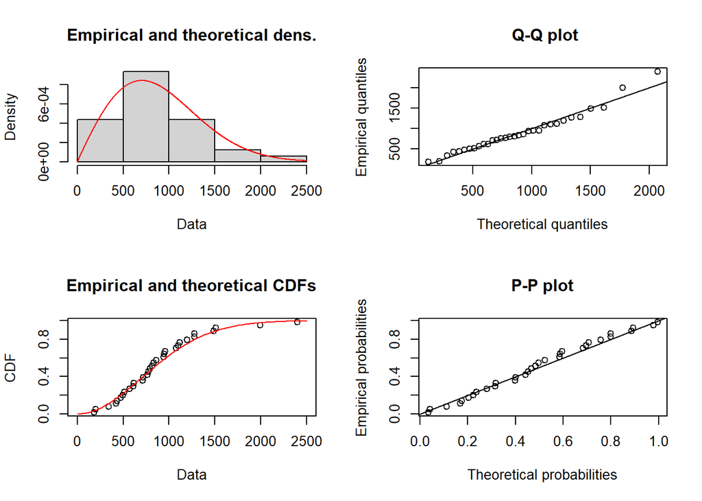

```r
inicio<-list(shape=lluvias_Wei$par[1], scale= 1/lluvias_Wei$par[2])

bondad1<-fitdist(y, "weibull", method = "mle", start = inicio,
                 optim.method="Nelder-Mead")
plot(bondad1)
```

```r
print("Parámetros: "); bondad1$estimate
```

```
## [1] "Parámetros: "
```

```
##       shape       scale
##    1.972516 1005.421226
```

```r
print("Errores Estándar: "); bondad1$sd
```

```
## [1] "Errores Estándar: "
```

```
##     shape     scale
##  0.258236 95.311900
```

## Histograma & Distribucion Ajustada

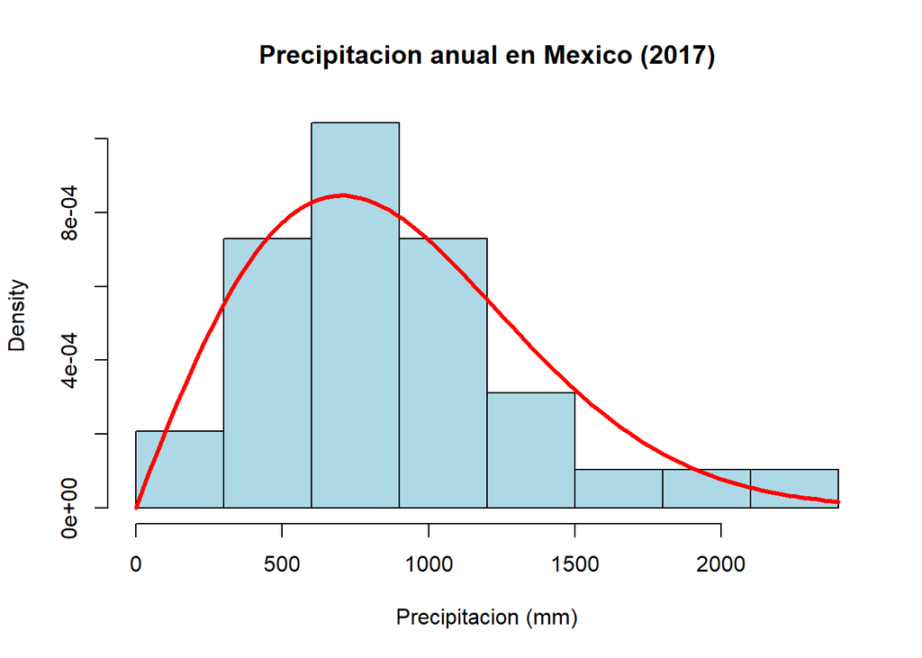

```r
hist(y,breaks=seq(0,2400,300),main= "Precipitacion anual en Mexico (2017)",
     xlab="Precipitacion (mm)", col="lightblue", probability  = T)
curve(dweibull(x, shape = bondad1$estimate[1], scale = bondad1$estimate[2]),
      col="red", lwd=3 , add=T)
```

## Comparación de Métodos

Recuperando los Criterios de Información de Akaike y Bayesianos de los modelos Exponencial y Gamma del trabajo realizado en clase y obteniendo los de Weibull de la última prueba realizada:

```r
AIC_exp=500.5257
BIC_exp=505.4572

AIC_gamma=482.3427
BIC_gamma=485.2742

AIC_wei=bondad1$aic
BIC_wei=bondad1$bic

op_dist<-c(AIC_exp, AIC_gamma,AIC_wei, BIC_exp, BIC_gamma, BIC_wei)

min(op_dist)
```

```
## [1] 482.3427
```

- El módelo mejor al problema fue el modelo Gamma ya que su AIC es menor a los demás criterios*